# Project: Investigate a Dataset (No-Show Appointments'Brazil')

- Introduction
- Data Wrangling
- Exploratory Data Analysis
- Conclusions

## Introduction

> This dataset collects information from 100k medical appointments in Brazil and is focused on the question of whether or not patients show up for their appointment. A number of characteristics about the patient are included in each row.  
> -‘ScheduledDay’ tells us on what day the patient set up their appointment.  
> -‘Neighborhood’ indicates thelocation of the hospital.  
> -‘Scholarship’ indicates whether or not the patient is enrolled in Brasilian welfare program Bolsa Família.  
> -Be careful about the encoding of the last column: it says ‘No’ if the patient showed up to their appointment, and ‘Yes’ if they did not show up.

```python
import numpy as np
import pandas as pd
import seaborn as sns
import matplotlib.pyplot as plt
%matplotlib inline
```

## Data Wrangling

> **Tip**: In this section of the report, you will load in the data, check for cleanliness, and then trim and clean your dataset for analysis. Make sure that you document your steps carefully and justify your cleaning decisions.

### General Properties

```python
# Load your data and print out a few lines. Perform operations to inspect data
#   types and look for instances of missing or possibly errant data.
df = pd.read_csv('noshowappointments-kagglev2-may-2016.csv')
```

```python
df.head()
```

|  | PatientId | AppointmentID | Gender | ScheduledDay | AppointmentDay | Age | Neighbourhood | Scholarship | Hipertension | Diabetes | Alcoholism | Handcap | SMS_received | No-show |
| --- | --- | --- | --- | --- | --- | --- | --- | --- | --- | --- | --- | --- | --- | --- |
| 0 | 2.987250e+13 | 5642903 | F | 2016-04-29T18:38:08Z | 2016-04-29T00:00:00Z | 62 | JARDIM DA PENHA | 0 | 1 | 0 | 0 | 0 | 0 | No |
| 1 | 5.589978e+14 | 5642503 | M | 2016-04-29T16:08:27Z | 2016-04-29T00:00:00Z | 56 | JARDIM DA PENHA | 0 | 0 | 0 | 0 | 0 | 0 | No |
| 2 | 4.262962e+12 | 5642549 | F | 2016-04-29T16:19:04Z | 2016-04-29T00:00:00Z | 62 | MATA DA PRAIA | 0 | 0 | 0 | 0 | 0 | 0 | No |
| 3 | 8.679512e+11 | 5642828 | F | 2016-04-29T17:29:31Z | 2016-04-29T00:00:00Z | 8 | PONTAL DE CAMBURI | 0 | 0 | 0 | 0 | 0 | 0 | No |
| 4 | 8.841186e+12 | 5642494 | F | 2016-04-29T16:07:23Z | 2016-04-29T00:00:00Z | 56 | JARDIM DA PENHA | 0 | 1 | 1 | 0 | 0 | 0 | No |

```python
df.shape
```

```
(110527, 14)
```

```python
df.info()
```

```
<class 'pandas.core.frame.DataFrame'>
RangeIndex: 110527 entries, 0 to 110526
Data columns (total 14 columns):
 #   Column          Non-Null Count   Dtype
---  ------          --------------   -----
 0   PatientId       110527 non-null  float64
 1   AppointmentID   110527 non-null  int64
 2   Gender          110527 non-null  object
 3   ScheduledDay    110527 non-null  object
 4   AppointmentDay  110527 non-null  object
 5   Age             110527 non-null  int64
 6   Neighbourhood   110527 non-null  object
 7   Scholarship     110527 non-null  int64
 8   Hipertension    110527 non-null  int64
 9   Diabetes        110527 non-null  int64
 10  Alcoholism      110527 non-null  int64
 11  Handcap         110527 non-null  int64
 12  SMS_received    110527 non-null  int64
 13  No-show         110527 non-null  object
dtypes: float64(1), int64(8), object(5)
memory usage: 11.8+ MB
```

No Missing Data

```python
df.describe()
```

|  | PatientId | AppointmentID | Age | Scholarship | Hipertension | Diabetes | Alcoholism | Handcap | SMS_received |
| --- | --- | --- | --- | --- | --- | --- | --- | --- | --- |
| count | 1.105270e+05 | 1.105270e+05 | 110527.000000 | 110527.000000 | 110527.000000 | 110527.000000 | 110527.000000 | 110527.000000 | 110527.000000 |
| mean | 1.474963e+14 | 5.675305e+06 | 37.088874 | 0.098266 | 0.197246 | 0.071865 | 0.030400 | 0.022248 | 0.321026 |
| std | 2.560949e+14 | 7.129575e+04 | 23.110205 | 0.297675 | 0.397921 | 0.258265 | 0.171686 | 0.161543 | 0.466873 |
| min | 3.921784e+04 | 5.030230e+06 | -1.000000 | 0.000000 | 0.000000 | 0.000000 | 0.000000 | 0.000000 | 0.000000 |
| 25% | 4.172614e+12 | 5.640286e+06 | 18.000000 | 0.000000 | 0.000000 | 0.000000 | 0.000000 | 0.000000 | 0.000000 |
| 50% | 3.173184e+13 | 5.680573e+06 | 37.000000 | 0.000000 | 0.000000 | 0.000000 | 0.000000 | 0.000000 | 0.000000 |
| 75% | 9.439172e+13 | 5.725524e+06 | 55.000000 | 0.000000 | 0.000000 | 0.000000 | 0.000000 | 0.000000 | 1.000000 |
| max | 9.999816e+14 | 5.790484e+06 | 115.000000 | 1.000000 | 1.000000 | 1.000000 | 1.000000 | 4.000000 | 1.000000 |

*Mean Age of the patients equals 37 years old.*  
Maximum Age of the patients equals 115 years old.  
* The is a mistake with one of the patients' age as it shows that the age equals -1.

```python
df.dtypes
```

```
PatientId         float64
AppointmentID       int64
Gender             object
ScheduledDay       object
AppointmentDay     object
Age                 int64
Neighbourhood      object
Scholarship         int64
Hipertension        int64
Diabetes            int64
Alcoholism          int64
Handcap             int64
SMS_received        int64
No-show            object
dtype: object
```

# Cleaning Data

```python
# We will not use the PatientId, AppointmentID, ScheduledDay, and AppointmentDay. So, We will start cleaning by dropping those coloumns
df.drop(['PatientId','AppointmentID','ScheduledDay','AppointmentDay'],axis=1,inplace=True)
```

```python
df.head()
```

[output not shown]

```python
df.rename(columns= lambda x: x.replace('-','_'))
```

|  | Gender | Age | Neighbourhood | Scholarship | Hipertension | Diabetes | Alcoholism | Handcap | SMS_received | No_show |
| --- | --- | --- | --- | --- | --- | --- | --- | --- | --- | --- |
| 0 | F | 62 | JARDIM DA PENHA | 0 | 1 | 0 | 0 | 0 | 0 | No |
| 1 | M | 56 | JARDIM DA PENHA | 0 | 0 | 0 | 0 | 0 | 0 | No |
| 2 | F | 62 | MATA DA PRAIA | 0 | 0 | 0 | 0 | 0 | 0 | No |
| 3 | F | 8 | PONTAL DE CAMBURI | 0 | 0 | 0 | 0 | 0 | 0 | No |
| 4 | F | 56 | JARDIM DA PENHA | 0 | 1 | 1 | 0 | 0 | 0 | No |
| ... | ... | ... | ... | ... | ... | ... | ... | ... | ... | ... |
| 110522 | F | 56 | MARIA ORTIZ | 0 | 0 | 0 | 0 | 0 | 1 | No |
| 110523 | F | 51 | MARIA ORTIZ | 0 | 0 | 0 | 0 | 0 | 1 | No |
| 110524 | F | 21 | MARIA ORTIZ | 0 | 0 | 0 | 0 | 0 | 1 | No |
| 110525 | F | 38 | MARIA ORTIZ | 0 | 0 | 0 | 0 | 0 | 1 | No |
| 110526 | F | 54 | MARIA ORTIZ | 0 | 0 | 0 | 0 | 0 | 1 | No |

110527 rows × 10 columns

```python
# It was found that Handcap coloumn states either patient is handcapped or not (0 or 1), but it was found that there is a values of 2, 3, and 4 so we had to remove them.
i = 2
for i in range (2,5):
    index_names = df[df['Handcap'] == i].index
    df.drop(index_names, inplace=True)
```

```python
# Verify results
df['Handcap'].unique()
```

```
array([0, 1], dtype=int64)
```

## Exploratory Data Analysis

### General Data Showing

[figure not shown]

```python
df.hist(figsize=[10,10]);
```

```python
# Assign Names to patients who showed and doesn't showed to make the recalling and comparison easier
Show = df['No-show'] == 'No'
No_Show = df['No-show'] == 'Yes'
```

### Research Question 1 (Descovering If Age influence showing for the appointment)

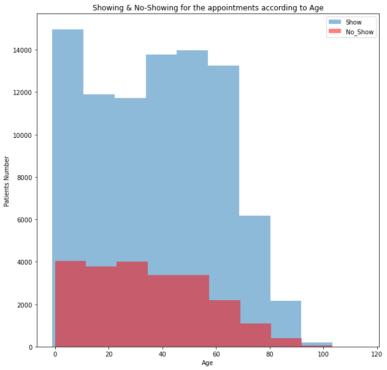

```python
Age_show = df['Age'][Show]
Age_no_show = df['Age'][No_Show]
plt.figure(figsize=[10,10])
plt.hist(Age_show,alpha=0.5,label='Show')
plt.hist(Age_no_show,alpha=0.5,label='No_Show',color='Red')
plt.legend()
plt.title('Showing & No-Showing for the appointments according to Age')
plt.xlabel('Age')
plt.ylabel('Patients Number');
```

### Research Question 2 (Descovering If Gender influence showing for the appointment)

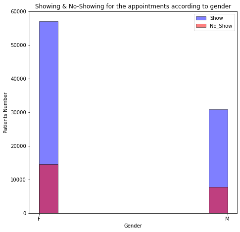

```python
Gender_show = df['Gender'][Show]
Gender_no_show = df['Gender'][No_Show]
plt.figure(figsize=[7.50, 7.50])
plt.hist(Gender_show,alpha=0.5,label='Show',color='Blue',edgecolor='black',)
plt.hist(Gender_no_show,alpha=0.5,label='No_Show',color='Red',edgecolor='black')
plt.legend()
plt.title('Showing & No-Showing for the appointments according to gender')
plt.xlabel('Gender')
plt.ylabel('Patients Number');
```

```python
print(df['Gender'][Show].value_counts())
print(df['Gender'][No_Show].value_counts())
```

```
F    57163
M    30887
Name: Gender, dtype: int64
F    14568
M     7710
Name: Gender, dtype: int64
```

- Gender isn't significant to compare by it (Females Showed for appointments are more than males and females who didn't show is more thant males).

### Research Question 3 (Descovering If enrolling in Brazilian Welfare Program Bolsa Family influence showing for the appointment)

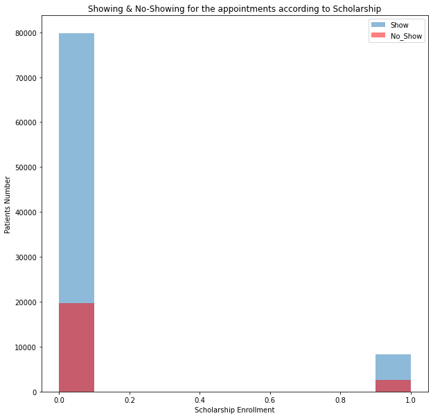

```python
Scholarsip_show = df['Scholarship'][Show]
Scholarsip_no_show = df['Scholarship'][No_Show]
plt.figure(figsize=[10,10])
plt.hist(Scholarsip_show,alpha=0.5,label='Show')
plt.hist(Scholarsip_no_show,alpha=0.5,label='No_Show',color='Red')
plt.legend()
plt.title('Showing & No-Showing for the appointments according to Scholarship')
plt.xlabel('Scholarship Enrollment')
plt.ylabel('Patients Number');
```

```python
print(df['Scholarship'][Show].value_counts())
print(df['Scholarship'][No_Show].value_counts())
```

```
0    79784
1     8266
Name: Scholarship, dtype: int64
0    19701
1     2577
Name: Scholarship, dtype: int64
```

### Research Question 4 (Descovering If Alcoholism influence showing for the appointment)

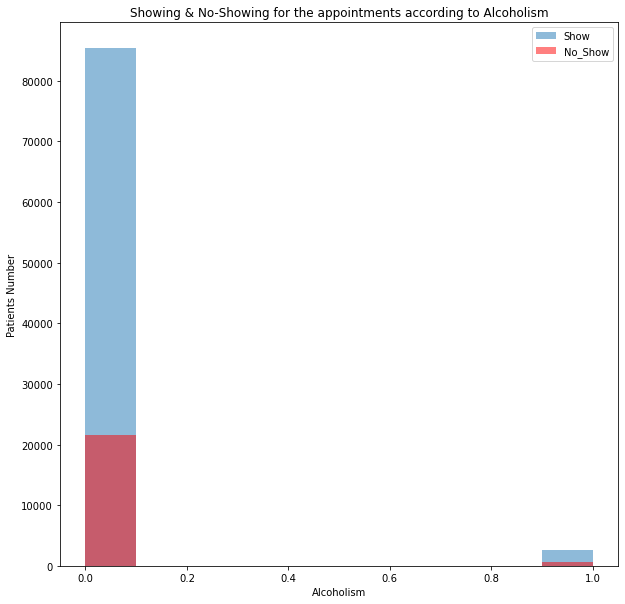

```python
Alcoholism_show = df['Alcoholism'][Show]
Alcoholism_no_show = df['Alcoholism'][No_Show]
plt.figure(figsize=[10,10])
plt.hist(Alcoholism_show,alpha=0.5,label='Show')
plt.hist(Alcoholism_no_show,alpha=0.5,label='No_Show',color='Red')
plt.legend()
plt.title('Showing & No-Showing for the appointments according to Alcoholism')
plt.xlabel('Alcoholism')
plt.ylabel('Patients Number');
```

```python
print(df['Alcoholism'][Show].value_counts())
print(df['Alcoholism'][No_Show].value_counts())
```

```
0    85373
1     2677
Name: Alcoholism, dtype: int64
0    21603
1      675
Name: Alcoholism, dtype: int64
```

- Alcoholism isn't significant to compare by it (Number of non-alcholic who showed is more than the alcoholic who showed but also number of non-alcholic who didn't show is more than the alcoholic who didn't show).

### Research Question 5 (Descovering If Handicap influence showing for the appointment)

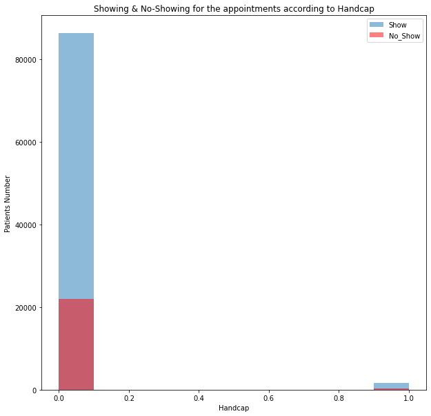

```python
Handicap_show = df['Handcap'][Show]
Handicap_no_show = df['Handcap'][No_Show]
plt.figure(figsize=[10,10])
plt.hist(Handicap_show,alpha=0.5,label='Show')
plt.hist(Handicap_no_show,alpha=0.5,label='No_Show',color='Red')
plt.legend()
plt.title('Showing & No-Showing for the appointments according to Handcap')
plt.xlabel('Handcap')
plt.ylabel('Patients Number');
```

```python
print(df['Handcap'][Show].value_counts())
print(df['Handcap'][No_Show].value_counts())
```

```
0    86374
1     1676
Name: Handcap, dtype: int64
0    21912
1      366
Name: Handcap, dtype: int64
```

- Handicapping isn't significant to compare by it (Number of Handicapped who showed is more than the Handicapped who didn't show).

### Research Question 6 (Descovering If Chronic diseases (Hypertension & Diabetes) influence showing for the appointment)

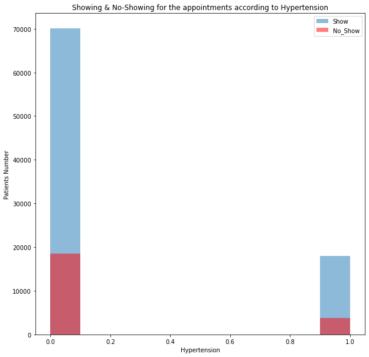

```python
Hipertension_show = df['Hipertension'][Show]
Hipertension_no_show = df['Hipertension'][No_Show]
plt.figure(figsize=[10,10])
plt.hist(Hipertension_show,alpha=0.5,label='Show')
plt.hist(Hipertension_no_show,alpha=0.5,label='No_Show',color='Red')
plt.legend()
plt.title('Showing & No-Showing for the appointments according to Hypertension')
plt.xlabel('Hypertension')
plt.ylabel('Patients Number');
```

```python
print(df['Hipertension'][Show].value_counts())
print(df['Hipertension'][No_Show].value_counts())
```

```
0    70082
1    17968
Name: Hipertension, dtype: int64
0    18530
1     3748
Name: Hipertension, dtype: int64
```

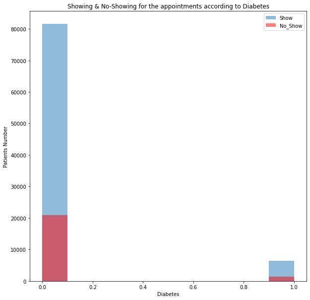

```python
diabetes_show = df['Diabetes'][Show]
diabetes_no_show = df['Diabetes'][No_Show]
plt.figure(figsize=[10,10])
plt.hist(diabetes_show,alpha=0.5,label='Show')
plt.hist(diabetes_no_show,alpha=0.5,label='No_Show',color='Red')
plt.legend()
plt.title('Showing & No-Showing for the appointments according to Diabetes')
plt.xlabel('Diabetes')
plt.ylabel('Patients Number');
```

```python
print(df['Diabetes'][Show].value_counts())
print(df['Diabetes'][No_Show].value_counts())
```

```
0    81572
1     6478
Name: Diabetes, dtype: int64
0    20856
1     1422
Name: Diabetes, dtype: int64
```

- Chronic Diseases (Hypertension & Diabetes) is insignficant.

### Research Question 7 (Descovering If Receiving Reminding SMS influence showing for the appointment)

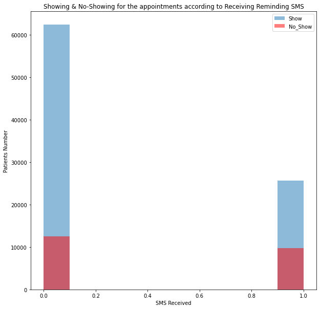

```python
SMS_show = df['SMS_received'][Show]
SMS_no_show = df['SMS_received'][No_Show]
plt.figure(figsize=[10,10])
plt.hist(SMS_show,alpha=0.5,label='Show')
plt.hist(SMS_no_show,alpha=0.5,label='No_Show',color='Red')
plt.legend()
plt.title('Showing & No-Showing for the appointments according to Receiving Reminding SMS')
plt.xlabel('SMS Received')
plt.ylabel('Patients Number');
```

- According to the results, Sending a reminder SMS doesn't reinforce the probability of patients to attend the appointment which is a little bit strange as the people who received SMS & does show for the appointment is way less than people who didn't receive SMS and showed for the appointment.

### Research Question 8 (Descovering If Neighbourhood where patients live at influence showing for the appointment)

[figure not shown]

```python
Neighbourhood_show = df['Neighbourhood'][Show]
Neighbourhood_no_show = df['Neighbourhood'][No_Show]
plt.figure(figsize=[15,15])
Neighbourhood_show.value_counts().plot(kind = 'bar',label='Show',color='Blue',alpha = 0.7)
Neighbourhood_no_show.value_counts().plot(kind = 'bar',label='No_Show',color='Red',alpha = 0.75)
plt.legend()
plt.title('Showing & No-Showing for the appointments according to Neighbourhood')
plt.xlabel('Neighbourhood')
plt.ylabel('Patients Number');
```

- It is very obvious that the Neighbourhood affects the number of patients shows for the appointments at the clinic, To Know why we must gather data about those neighbourhoods and answer some questions.  
  How far the neighbourhood from the clinic?  
  How is the financial level of every neighbourhood?  
  etc,...

## Conclusions

- Age of patients have direct effect on showing for the appointments.
- Showing Patients varies with the neighbourhood they live at due to unknown reasons becuase of lack of data about those neighbourhoods.
- Althougth it was unexpected receiving a reminder SMS doesnot make the patient shows for the appointment.
- There is no direct correlation between patients shows or not for the appointments and some characteristics as Gender, Chronic diseases, and Disabilities.